# Session 1 | R Language

Devrato Roy

May 24, 2021

# Index

### 1. Intro to *R*

### 2. Why *R*

### 3. Setup *R* & *RStudio* Environment

### 4. Variables And Operators

> 4.1 Variables

> 4.2 Arithmetic Operators

> 4.3 Logical Operators

> 4.4 Conditional Statements

### **Intro to *R***

R was developed by a group of statisticians who wanted an open-source alternative to the costly proprietary options that were (and still are) popular.

Because it was created by statisticians (instead of computer scientists), R has some quirky aspects to it that take some time to get used to.

### **Why *R***

R is mainly used for statistical analysis while Python provides a more general approach to data science.

R has now one of the richest ecosystems to perform data analysis.It is possible to find a library for whatever the analysis you want to perform.

The rich variety of library makes R the first choice for statistical analysis, especially for specialized analytical work.

### **Setup *R* & *RStudio* on your local machine**

#### For installing R and RStudio head to the links below

> [R Downloadable Link](https://cloud.r-project.org/)

> [RStudio Downloadable Link](https://www.rstudio.com/products/rstudio/)

#### Or Setup Using Anaconda

##### Go ahead and enter these commands into your Anaconda Prompt & We’ll be good to go.

> conda install r-essentials –yes

> conda install -c r rstudio –yes

### RStudio Environment

[figure not shown]

#### Now Check your working directory and then set it accordingly by entering these commands in the console given below.

> getwd(‘Current Location’)

> setwd(‘Desired location’)

### **Basics Of *R***

##### Data Types in R

So R has basically 4 data types :

- numeric: R by default stores a number as a double be it integer or decimal.To determine a integer explicitly one has to put an *L* at the end of the number.
- character: a.k.a the string values could be anything inside "".
- complex: It is to store complex numbers in the form of a + b(i).
- Boolean: It can be either TRUE / FALSE.

```r
typeof(123)
```

```
## [1] "double"
```

```r
typeof(123L)
```

```
## [1] "integer"
```

```r
typeof('Hello World')
```

```
## [1] "character"
```

```r
typeof(2+3i)
```

```
## [1] "complex"
```

*Indexing in R starts from 1 whereas in python it starts from 0.*

##### Variables

Rules for naming a variable in R:

- A variable name must start with a letter and can be a combination of letters, digits, period(.)and underscore(_).
- If it starts with period(.), it cannot be followed by a digit.

```r
first_var <- 123

second_var <- 234

sum <- first_var + second_var

print(sum)
```

```
## [1] 357
```

##### Concatenation

For concateneation of two strings we use paste() function.

```r
char_a <- 'Hello'
char_b <- 'World'

char_a
```

```
## [1] "Hello"
```

```r
char_b
```

```
## [1] "World"
```

```r
char_c <- paste(char_a, char_b)
char_c
```

```
## [1] "Hello World"
```

##### Operators

In other programming language, it is common to use = as an assignment operator. In R, we can use both = and <- as assignment operators.

However, <- is preferred in most cases because the = operator can be forbidden in some context in R.

x <- 3 is equal to 3 -> x

*<<- is a Global Assigning Operator.*

Arithmetic Operators

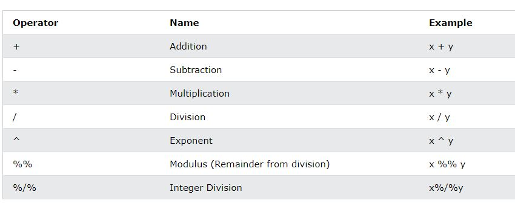

```r
x <- 5
y <- 16

#modulo
y%%x
```

```
## [1] 1
```

```r
#exponent
y^x
```

```
## [1] 1048576
```

Logical Operators

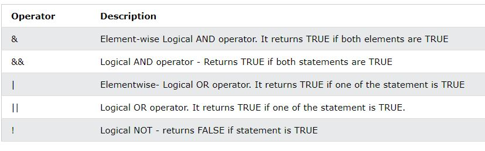

```r
x <- c(TRUE,FALSE,0,6)
y <- c(FALSE,TRUE,FALSE,TRUE)

!x
```

```
## [1] FALSE  TRUE  TRUE FALSE
```

```r
x&y
```

```
## [1] FALSE FALSE FALSE  TRUE
```

```r
x&&y
```

```
## [1] FALSE
```

```r
x|y
```

```
## [1]  TRUE  TRUE FALSE  TRUE
```

```r
x||y
```

```
## [1] TRUE
```

Math Functions

Basic math functions like max(), min(), sqrt() etc.

```r
max(5, 10, 15)
```

```
## [1] 15
```

```r
min(5, 10, 15)
```

```
## [1] 5
```

```r
#returns square root
sqrt(225)
```

```
## [1] 15
```

```r
#returns the absolute value of a number
abs(-4.7)
```

```
## [1] 4.7
```

```r
#rounds a number to its upwards integer
ceiling(1.4)
```

```
## [1] 2
```

```r
#rounds a number to its downwards integer
floor(1.4)
```

```
## [1] 1
```

##### Loops

###### while loops syntax

```r
i <- 1
while (i < 6) {
  print(i)
  i <- i + 1
}
```

```
## [1] 1
## [1] 2
## [1] 3
## [1] 4
## [1] 5
```

###### for loops syntax

```r
for (x in 1:10) {
  print(x)
}
```

```
## [1] 1
## [1] 2
## [1] 3
## [1] 4
## [1] 5
## [1] 6
## [1] 7
## [1] 8
## [1] 9
## [1] 10
```

##### Conditional Statements

- Nested If statements

```r
x <- rnorm(1)

if (x > 1) {
  print("")
  if (x > 20) {
    print("and also above 20!")
  } else {
    print("but not above 20.")
  }
} else {
  print("below 10.")
}
```

```
## [1] "below 10."
```

- Else-if Statements

```r
x <- rnorm(1)

if(x>1){
 ans <- 'Greater than 1'
}else if(x >= -1){
  ans <- 'Between -1 & 1'
}else{
  ans <- 'Less than 1'
}

print(x)
```

```
## [1] -0.0482938
```

```r
print(ans)
```

```
## [1] "Between -1 & 1"
```

##### In the above examples, we use conditinal statements to group the randomly generated number x (the rnorm function is similar to the random() fxn in python).